# Task 4 - Part 1 - Biodiversity of ant communities along an elevational gradient

## 0 - Setup

First of all we load the needed libraries and set the default theme for ggplot

```r
library(betapart)
library(iNEXT)
library(readxl)
library(tidyverse)
library(vegan)

theme_set(theme_bw())
```

#### Dataset: dat4_ants_elevation.xlsx

This data set includes samples of ant communities along an elevational gradient. The sampling used a hierarchically nested design. The basic sampling unit are 1m2 plots for which abundance counts for all species are available.

Sites ranged in elevation from 379-1828 m and were in relatively undisturbed deciduous forest sites, away from trails. At each site, there is one randomly placed 50 × 50 m plot, from which 16 1-m2 quadrats were arranged in a nested design: 10 x 10 m subplots were placed in the corners of each 50 x 50 m plot, and 1-m2 quadrats were placed in the corners of each 10 x 10 m subplot, for a total of 16 1-m2 quadrats per site. Ants were sampled by collecting all the leaflitter within each quadrat and sifting through it with a coarse mesh screen (1-cm grid) to remove the largest fragments and concentrate the fine litter. Concentrated litter from each quadrat was then put in its own mini-Winkler sacks for 2 days in the lab. After 2 days, all worker ants were extracted and enumerated.

```r
data_ants <- read_excel("../data/dat4_ants_elevation.xlsx")
```

1 - Number of samples

#### How many samples (1-m2 plots) were taken at each elevation?

```r
samples <- data_ants %>%
  count(elevation_m, name = "n_samples")
```

Two sites shared the same elevation (941m). Therefore we have 32 samples for this elevation, while 16 samples were taken for every other elevation.

## 2 - Alpha and gamma diversity for each elevation

To assess diversity measures we work on a species by sites table, removing the first 4 columns of our full dataset:

```r
spec_table <- data_ants %>%
  select(-(1:4))
```

### 2.1 - Alpha diversity

First we assess measures for alpha diversity (for each single site) and store the information in a new tibble called data_alpha.

```r
S <- specnumber(spec_table)
N <- rowSums(spec_table)
shannon <- diversity(spec_table, index = "shannon")
simpson <- diversity(spec_table, index = "simpson")
evenness <- shannon / log(S)

data_alpha <- (tibble(elevation_m = data_ants$elevation_m,
                      site = data_ants$site,
                      S = S,
                      N = N,
                      shannon = shannon,
                      simpson = simpson,
                      evenness = evenness))
rm(S, N, shannon, simpson, evenness, site)
```

Note that, in many cases only one species was found in a sample, leading to a Shannon Index of 0. In these cases, of course, evenness can’t be assessed and the corresponding entries in the tibble are *NA*s.

In order to plot all indices together (with facet_wrap) we need to change the structure of the tibble to a long format, with one column storing the index names and one column storing the corresponding values.

```r
data_alpha_l <- data_alpha %>%
  pivot_longer(S:evenness,
               names_to = "index",
               values_to = "value")
```

Now we can plot all indices along the elevation gradient.

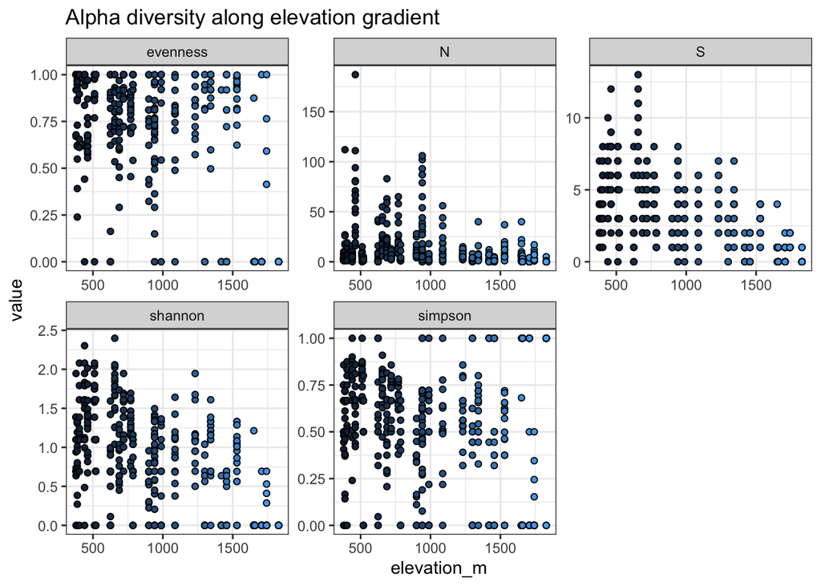

```r
ggplot(data_alpha_l, aes(elevation_m, value, fill = elevation_m)) +
  geom_point(shape = 21) +
  facet_wrap(~index, scales = "free") +
  labs(title = "Alpha diversity along elevation gradient") +
  guides(fill = "none")
```

```r
rm(data_alpha_l)
```

This is not a good plot. Many samples can’t be seen because they overlap and many others were omitted because of *NA*s. I’m planning an alternative version where only the means will be plotted as points and the mins and maxs will be plotted as ranges. Still, there’s the issue with the edge cases (simpson = 0 or 1, evenness = 0 or 1) which might still look awkward. Not really sure how to tackle that yet.

### 2.2 - Gamma diversity

The same can be done for gamma diversity, by just pooling together all samples from each elevation.

```r
spec_pooled <- data_ants %>%
  # we keep elevation_m for grouping until we don't need it anymore
  select(-(2:4)) %>%
  group_by(elevation_m) %>%
  summarise(across(everything(), sum)) %>%
  # now we can get rid of elevation_m
  column_to_rownames(var = "elevation_m")
```

We now have a species table with only one row for each elevation and the sum of abundances for each species by elevation.

Again, we can assess measures for the different diversity indices and store those in a new tibble called data_gamma.

```r
S <- specnumber(spec_pooled)
N <- rowSums(spec_pooled)
shannon <- diversity(spec_pooled, index = "shannon")
simpson <- diversity(spec_pooled, index = "simpson")
evenness <- shannon / log(S)

# extract vector with all levels of elevation
elevations <- unique(data_ants$elevation_m)

data_gamma <- (tibble(elevation_m = elevations,
                      S = S,
                      N = N,
                      shannon = shannon,
                      simpson = simpson,
                      evenness = evenness))
rm(S, N, shannon, simpson, evenness)
```

As we did for alpha diversity, we now change the tibble to the long format.

```r
data_gamma_l <- data_gamma %>%
  pivot_longer(cols = S:evenness,
               names_to = "index",
               values_to = "value")
```

Now we can nicely plot all indices together along the elevation gradient.

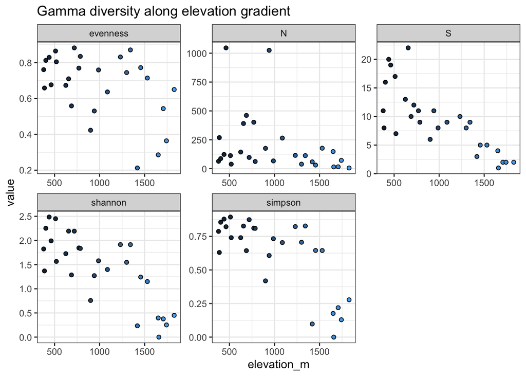

```r
ggplot(data_gamma_l, aes(elevation_m, value, fill = elevation_m)) +
  geom_point(shape = 21) +
  facet_wrap(~index, scales = "free") +
  labs(title = "Gamma diversity along elevation gradient") +
  guides(fill = "none")
```

```r
rm(data_gamma_l)
```

## 3 - Rarefaction

I will discuss this section in a separate quarto document, where I propose different approaches for analysis and visualization.

## 4 - Beta diversity

To assess beta diversity for each elevation, I chose Whittaker’s Index so far (not really thought through though). I used the function provided by Felix during the course.

```r
beta_w <- function(community)
{
  require(vegan)
  gamma <- specnumber(colSums(community))
  alpha <- mean(specnumber(community))
  return(gamma/alpha)
}
```

I changed the species table to a presence-absence table, since this is the format we used in the course.

```r
data_pa <- spec_table
data_pa[data_pa > 0] <- 1
```

This time I want to iterate over elevations with a for-loop, so beforehand I initialized an empty tibble to store the measures assessed during the iteration.

```r
data_beta <- tibble(elevation_m = numeric(),
                    whittaker = numeric(),
                    beta.SIM = numeric(),
                    beta.SNE = numeric(),
                    beta.SOR = numeric())
```

Now we can iterate over the data and compute for one elevation at a time.

```r
# For each elevation:
for (lvl in elevations) {
  # We extract the corresponding subset from the new PA-tibble.
  subset <- data_pa[data_ants$elevation_m == lvl,]

  # We assess the index for the row of data_beta to add current entries
  i <- match(lvl, elevations)

  # We add values for elevation_m and for Whittaker's beta diversity
  data_beta[i,]$elevation_m <- lvl
  data_beta[i,]$whittaker <- beta_w(subset)

  # For cases where we have more than 16 samples per elevation (see h941m)
  if (nrow(subset) > 16) {
    # We use beta-sample to rarefy to 16 samples
    sampled <- beta.sample(subset, index.family = "sor", sites = 16,
                           samples = 100)
    partitioning <- sampled$mean.values
    # We add the mean values for SIM, SNE and SOR to our data_beta tibble
    data_beta[i,]$beta.SIM <- round(partitioning[1], digits = 2)
    data_beta[i,]$beta.SNE <- round(partitioning[2], digits = 2)
    data_beta[i,]$beta.SOR <- round(partitioning[3], digits = 2)
  }
  # In all other cases
  else {
    # We have 16 samples, so we can use beta.multi
    partitioning <- beta.multi(subset)
    # and directly add the output to our data_beta tibble
    data_beta[i,]$beta.SIM <- round(partitioning$beta.SIM, digits = 2)
    data_beta[i,]$beta.SNE <- round(partitioning$beta.SNE, digits = 2)
    data_beta[i,]$beta.SOR <- round(partitioning$beta.SOR, digits = 2)
  }
}
```

### 4.1 - Whittaker’s beta

For the visualization I started with the Whittaker’s beta values only.

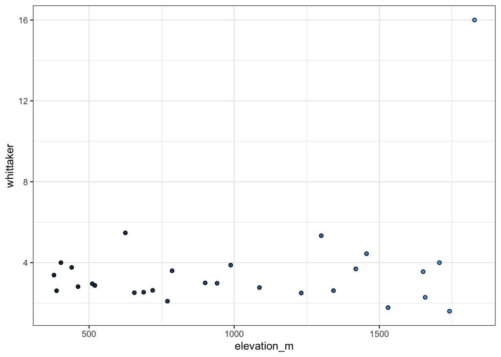

```r
ggplot(data_beta, aes(elevation_m, whittaker, fill = elevation_m)) +
  geom_point(shape = 21) +
  guides(fill = "none")
```

As we can see there is an outlier at max elevation (1828m). Here only 2 species were found in 2 different samples, leading to an extremely low mean alpha and very high beta (remember that beta_w = gamma / alpha).

I tried to plot again without the outlier, so points are not squished towards the lower part of the plot.

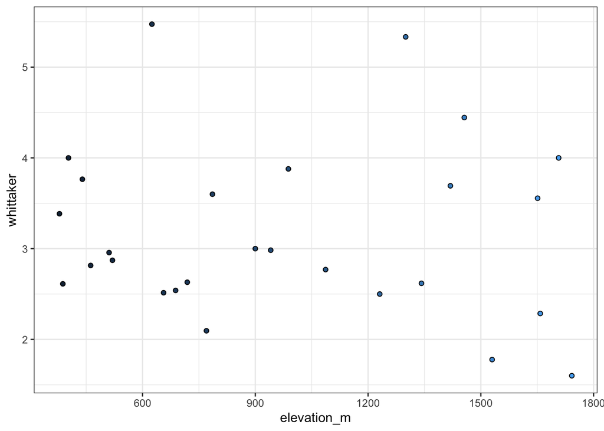

```r
ggplot(filter(data_beta, elevation_m < 1828),
       aes(elevation_m, whittaker, fill = elevation_m)) +
  geom_point(shape = 21) +
  guides(fill = "none")
```

A clear trend is not to be seen, even though it looks like beta diversity is slightly decreasing at higher elevations.

We could also consider using hill-numbers instead of Whittaker’s, since these will be used for the partitioning part anyways (if I remember well).

### 4.2 - Partitioning

Now to the partitioning of beta diversity into turnover and nestedness.

Again, we need to change the table to the long format for the facets. I wanted to plot turnover and nestedness as proportions of the total Sørensen dissimilarity, so in this step I also change the columns for beta.SIM and beta.SNE to prop_turn and prop_nest.

```r
data_beta_l <- data_beta %>%
  mutate(prop_nest = beta.SNE/beta.SOR,
         prop_turn = beta.SIM/beta.SOR) %>%
  select(-c(beta.SIM, beta.SNE)) %>%
  pivot_longer(beta.SOR:prop_turn,
               names_to = "index",
               values_to = "value")
```

Now we can plot the partitioning.

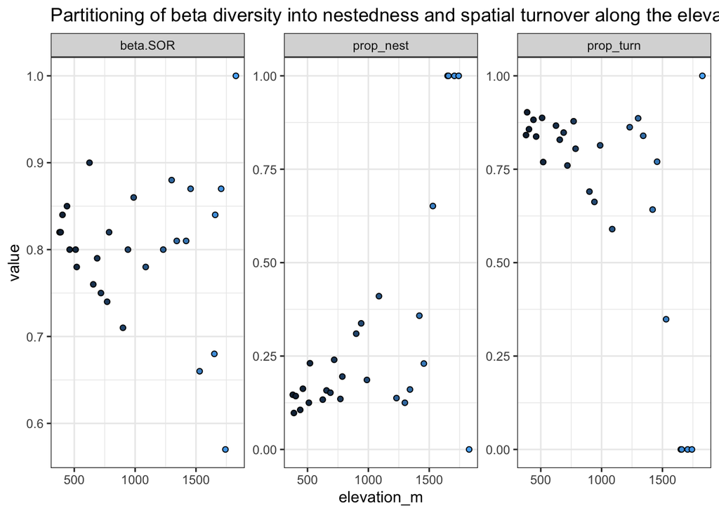

```r
ggplot(data_beta_l, aes(elevation_m, value, fill = elevation_m)) +
  geom_point(shape = 21) +
  facet_wrap(~index, scales = "free") +
  labs(title = "Partitioning of beta diversity into nestedness and spatial turnover along the elevation gradient") +
  guides(fill = "none")
```

We can see how the variance of Sørensen dissimilarity increases at higher elevations.

What is interesting here is the transition from turnover to nestedness at higher elevations, with complete nestedness at elevations >= 1651m! (except for the outlier h1828m).